# Isis Recruits

Naman Agarwal

November 2, 2018

```r
isis = read.csv("./isis.csv", header=TRUE)
```

Here’s the dataset from the reporter as given. I’m using the `dplyr` package to clean some of the columns (turning “t”s into TRUEs and other things like that.

```r
tToBool = function(val){
  return(ifelse(val == "t", TRUE, FALSE))
}

isis= isis %>% mutate(convicted = tToBool(convicted))
# fixes convicted column
# below lines do the same but fix other columns
isis = isis %>% mutate(is_minor_tf = tToBool(is_minor_tf))
isis = isis %>% mutate(is_charged = tToBool(is_charged))

isis[which(isis$is_minor_tf == TRUE),c("name", "age_at_arrest")]
```

```
##                name age_at_arrest
## 34  Ali Shukri Amin            17
## 102   Imran Rabbani            17
```

```r
isis[which(isis$is_charged == TRUE),c("name", "is_charged")]
```

```
##                              name is_charged
## 1               Basit Javed Sheik       TRUE
## 2                    Shelton Bell       TRUE
## 3              Eric Glenn Harroun       TRUE
## 4                 Abdella Tounisi       TRUE
## 5    Gufran Ahmed Kauser Mohammed       TRUE
## 6            Sinh Vinh Ngo Nguyen       TRUE
## 7            Mohamed Hussein Said       TRUE
## 8                Mufid A. Elfgeeh       TRUE
## 9          Shannon Maureen Conley       TRUE
## 10         Mohammad Hassan Hamdan       TRUE
## 11           Mohammed Hamzah Khan       TRUE
## 12              Nicholas Teausant       TRUE
## 13             Michael Todd Wolfe       TRUE
## 14                   Adam Dandach       TRUE
```

[output cut: 52 more lines]

```r
isis[which(isis$convicted == TRUE),c("name", "convicted")]
```

```
##                              name convicted
## 8                Mufid A. Elfgeeh      TRUE
## 9          Shannon Maureen Conley      TRUE
## 11           Mohammed Hamzah Khan      TRUE
## 12              Nicholas Teausant      TRUE
## 13             Michael Todd Wolfe      TRUE
## 14                   Adam Dandach      TRUE
## 15            Avin Marsalis Brown      TRUE
## 16              Akba Jihad Jordan      TRUE
## 17              Donald Ray Morgan      TRUE
## 18      Heather Elizabeth Coffman      TRUE
## 20                Abdullahi Yusuf      TRUE
## 21                   Rahatul Khan      TRUE
## 24  Abdurasul Hasanovich Juraboev      TRUE
## 33     Tairod Nathan Webster Pugh      TRUE
```

[output cut: 33 more lines]

There are two 17 year old recruits in the dataset, both arrested and charged in 2015. 66 of the people in the dataset were charged, of which 47 of them were convicted.

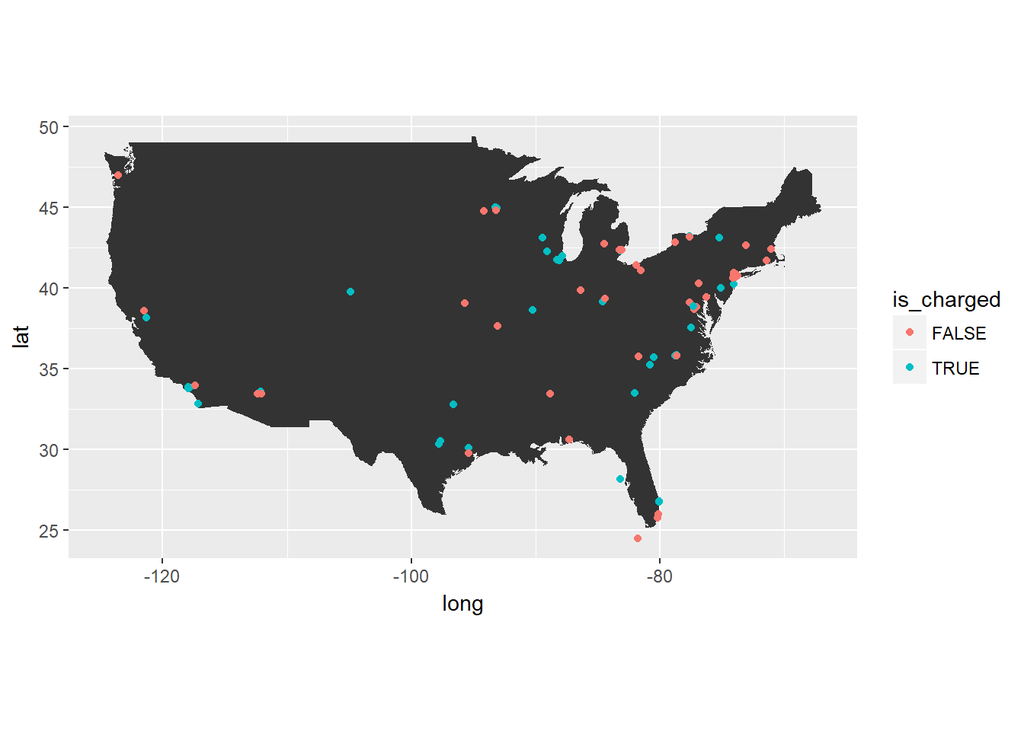

```r
usa <- map_data("usa")
ggplot() + geom_polygon(data = usa, aes(x=long, y = lat, group = group)) +
  coord_fixed(1.3) + geom_point(data=isis, aes(x=long, y=lat, color=is_charged))
```

We can see that some further data cleaning may be necessary to fix the lat/long data since there are points in the ocean near Florida, along with the fact that 3 of the recruits have no lat/long data at all. There doesn’t appear to be a correlation between geographic location and whether the person has been charged or not, based on the map above.

Two candidates, “Alexander Blair” and “Alexander E. Blair” are likely duplicates and should be resolved.

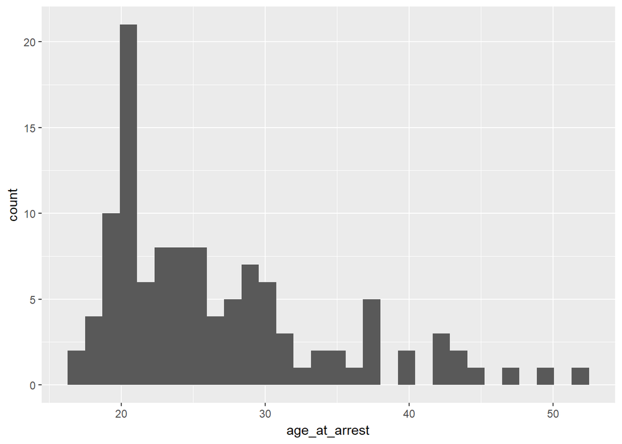

```r
ggplot() + geom_histogram(data=isis, aes(age_at_arrest))
```

We can see that the age distribution of these people skews younger, which makes sense. Note - there’s one person in the dataset who has no age listed, so that should be investigated and fixed.

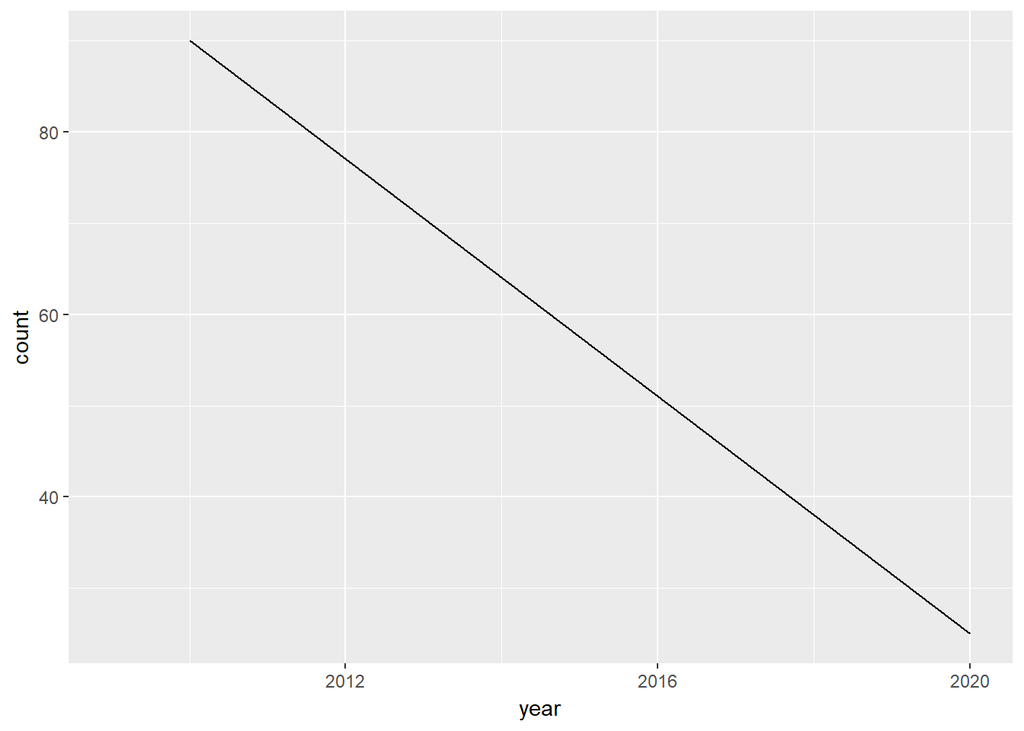

```r
ggplot(data=isis, aes(x=year)) + geom_line(aes(y=..count..), stat="bin", binwidth=10) + xlim(2009, 2020)
```